# Reproducible Research: Peer Assignment 1

## Loading and preprocessing the data

Show any code that is needed to:

1. Load the data (i.e. read.csv()),
2. Process/transform the data (if necessary) into a format suitable for your analysis.

For this assignment, the working directory will contain this script. The data source ‘activity.csv’ will be downloaded and un-zipped into the working directory if it does not already exist. ‘read.csv’ (or read.table) defaults are okay.

```r
if (!(file.exists("activity.csv"))) {
    message("Getting your data from the internet.")
    archiveUrl <- "https://d396qusza40orc.cloudfront.net/repdata%2Fdata%2Factivity.zip"
    archiveFile <- basename(URLdecode(archiveUrl))
    filePath <- file.path(getwd(), archiveFile)
    download.file(url = archiveUrl, destfile = filePath, method = "curl")
    if (file.exists(archiveFile)) {
        archiveIndex <- unzip(archiveFile)
    }
}

message("Reading 'activity.csv' into data frame.")
```

```
## Reading 'activity.csv' into data frame.
```

```r
df <- read.csv("activity.csv", header=TRUE)
```

#### OPTIONAL CODE AND NOTES ON DATES AND TIMES:

You might want to consider adding these two code chunks (below) to the loading and processing of data, though they are presented here as ‘options’ and are not included in this program.

```r
# Optional:
message("Seting up datetime field.")
df$datetime = as.POSIXct(paste(df$date, sprintf("%04d",df$interval)), format="%Y-%m-%d%H%M")
```

To extract the ‘hour’ and ‘minute’ from the POSIXct field ‘datetime’ as a ‘pretty’ character strings that can be grouped and used for plotting tick marks use a piece of code like this: (The ‘paste’ and the ‘format’ functions come from the R {base} package which is typically loaded by default.)

```r
# Optional:
paste(format(h$datetime,"%H"),format(h$datetime,"%M"),sep=":")
```

To extract the ‘weekdays’ from the POSIXct field ‘datetime’ (so the data can be grouped by weekdays versus weekends) use forms the ‘weekdays’ or ‘wdays’ functions that are in the R {lubridate} package. We will check for its presences and load the package as necessary. Note: that ‘lubridate’ has a ‘ymd’ function that can convert a character string into a POSIX date, obviating the need for datetime.

```r
if (!("lubridate" %in% installed.packages())) {
    message("One moment... need to install \"lubridate\" package.")
    install.packages("lubridate", quiet = TRUE)
}

if (!("lubridate" %in% loadedNamespaces())) {
    message("One moment... loading \"lubridate\" library.")
    library(lubridate, quietly = TRUE)
}
```

```
## One moment... loading "lubridate" library.
```

## What is mean total number of steps taken per day?

For this part of the assignment, you can ignore the missing values in the dataset.

1. Make a histogram of the total number of steps taken each day.
2. Calculate and report the mean and median total number of steps taken per day.

We will use the ‘dplyr’ package wherever we can make our data manipulations faster and more efficient by using the ‘dplyr’ piping of interim results.

```r
if (!("dplyr" %in% installed.packages())) {
    message("One moment... need to install \"dplyr\" package.")
    install.packages("dplyr", quiet = TRUE)
}

if (!("dplyr" %in% loadedNamespaces())) {
    message("One moment... loading \"dplyr\" library.")
    library(dplyr, quietly = TRUE)
}
```

```
## One moment... loading "dplyr" library.
##
##
```

GROUP_BY ‘date’ and SUMMARIZE (sum) ‘steps’; change the resulting ‘list’ to a ‘data.frame’ so ggplot can better digest the object.

```r
g <- df %>%
        group_by(date) %>%
            summarize(steps = sum(steps, na.rm=TRUE)) %>%
                data.frame()
```

We will use ‘ggplot2’ as our preferred plotting engine; however, any equally efficient methods (such as those in the ‘graphics’ package) will be used.

```r
if (!("ggplot2" %in% installed.packages())) {
    message("One moment... need to install \"ggplot2\" package.")
    install.packages("ggplot2", quiet = TRUE)
}

if (!("ggplot2" %in% loadedNamespaces())) {
    message("One moment... loading \"ggplot2\" library.")
    library(ggplot2, quietly = TRUE)
}
```

```
## One moment... loading "ggplot2" library.
```

```r
message("Plotting the frequency of daily steps taken during the 61 day period.")
```

```
## Plotting the frequency of daily steps taken during the 61 day period.
```

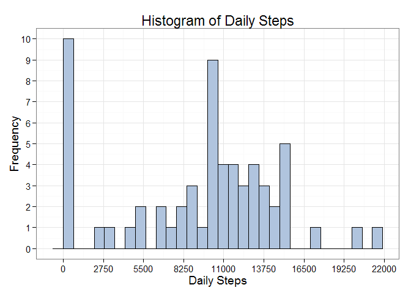

```r
print(
    ggplot(g) +
        geom_histogram(aes(x=steps),
                       col="black",
                       fill="lightsteelblue",
                       binwidth=diff(range(g$steps))/30) +
        scale_x_continuous(breaks=seq(0,22000,by=2750)) +
        scale_y_continuous(breaks=seq(0,10,by=1)) +
        theme_bw(base_size=14,base_family="sans") +
        labs(x="Daily Steps") +
        labs(y="Frequency") +
        labs(title="Histogram of Daily Steps") +
        theme(plot.title = element_text(size = rel(1.25)))
)
```

Report mean and median of distribution inside of message.

```r
message(sprintf("For the distribution \"Daily Steps\"
    the mean is: %.0f, and the median is: %.0f", mean(g$steps), median(g$steps)))
```

```
## For the distribution "Daily Steps"
##     the mean is: 9354, and the median is: 10395
```

## What is the average daily activity pattern?

1. Make a time series plot (i.e. type = “l”) of the 5-minute interval (x-axis) and the average number of steps taken, averaged across all days (y-axis).
2. Which 5-minute interval, on average across all the days in the dataset, contains the maximum number of steps?

GROUP_BY ‘interval’ and SUMMARIZE (mean) ‘steps’; change the resulting ‘list’ to a ‘data.frame’ (optional) so ggplot can better digest the object.

```r
h <- df %>%
        group_by(time = interval) %>%
            summarize(average = mean(steps, na.rm = TRUE))

message("Plotting the average daily activity in 5-minute intervals.")
```

```
## Plotting the average daily activity in 5-minute intervals.
```

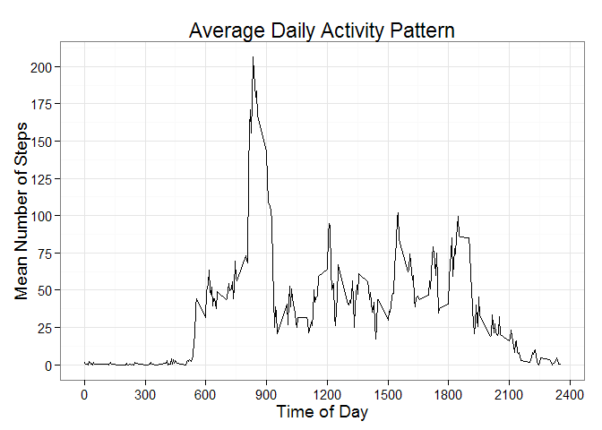

```r
print(
    ggplot(data = h, aes(x = time, y = average)) +
        geom_line(color = "black", size = 0.5) +
        scale_x_continuous(breaks=seq(0,2400,by=300)) +
        scale_y_continuous(breaks=seq(0,200,by=25)) +
        theme_bw(base_size=14,base_family="sans") +
        labs(x="Time of Day") +
        labs(y="Mean Number of Steps") +
        labs(title="Average Daily Activity Pattern") +
        theme(plot.title = element_text(size = rel(1.25)))
)
```

**Note:** Add ‘geom_area(fill = “lightsteelblue”) +’ (following geom_line) in the above ggplot code block to fill the area under the line segment.

```r
# Note: 'max' function returns maximum value in vector, whereas 'which.max'
# return index of vector that contains maximum value. We apply these to the 'h'
# object we create above.
#
message(sprintf("For the distribution \"Average Daily Activity Pattern\"
    the largest averge number of steps in a 5-minute interval is: %.0f,
    and the interval (time) is: %.0f", max(h$average),
    h$time[which.max(h$average)]))
```

```
## For the distribution "Average Daily Activity Pattern"
##     the largest averge number of steps in a 5-minute interval is: 206,
##     and the interval (time) is: 835
```

## Imputing missing values

Note that there are a number of days/intervals where there are missing values (coded as NA). The presence of missing days may introduce bias into some calculations or summaries of the data.

1. Calculate and report the total number of missing values in the dataset (i.e. the total number of rows with NAs)
2. Devise a strategy for filling in all of the missing values in the dataset. The strategy does not need to be sophisticated. For example, you could use the mean/median for that day, or the mean for that 5-minute interval, etc.
3. Create a new dataset that is equal to the original dataset but with the missing data filled in.
4. Make a histogram of the total number of steps taken each day and Calculate and report the mean and median total number of steps taken per day. Do these values differ from the estimates from the first part of the assignment? What is the impact of imputing missing data on the estimates of the total daily number of steps?

```r
message(sprintf("The number of missing (i.e. NA) values in the
    data set are: %.0f", sum(is.na(df$steps))))
```

```
## The number of missing (i.e. NA) values in the
##     data set are: 2304
```

Make a copy of the original data frame ‘df’. Use ‘mapply’ from the R {base} package to apply an anonymous fuction to each row of the copy. Use the ‘h’ data frame we created when calculated the average daily activity. Use the interval average of all days in the data set as a replacement value of the NA’s. Note: we will not ‘round’ the replacement values – the result of which is a change to the datatype for ‘steps’. This doesn’t matter for our plotting and reporting since our ‘h’ object (used in the prior step) is also of type ‘num’ for the steps value.

```r
ddf <- df

message(sprintf("The number of missing (i.e. NA) values in the \"revised\"
    data set are: %.0f", sum(is.na(ddf$steps))))
```

```
## The number of missing (i.e. NA) values in the "revised"
##     data set are: 2304
```

```r
ddf$steps <- mapply(function(x,y){ if(is.na(x)){ return(h$average[h$time==y])
                    } else { return(c(x))} }, df$steps, df$interval)

message(sprintf("The number of missing (i.e. NA) values in the \"revised\"
    data set (post-replacment) are: %.0f", sum(is.na(ddf$steps))))
```

```
## The number of missing (i.e. NA) values in the "revised"
##     data set (post-replacment) are: 0
```

Repeat the code block from ‘g’ above, applied to the revised dataset. GROUP_BY ‘date’ and SUMMARIZE (sum) ‘steps’; change the resulting ‘list’ to a ‘data.frame’ so ggplot can better digest the object.

```r
i <- ddf %>%
        group_by(date) %>%
            summarize(steps = sum(steps, na.rm=TRUE)) %>%
                data.frame()

message("Plotting the \"revised\" frequency of daily steps taken during the
    61 day period.")
```

```
## Plotting the "revised" frequency of daily steps taken during the
##     61 day period.
```

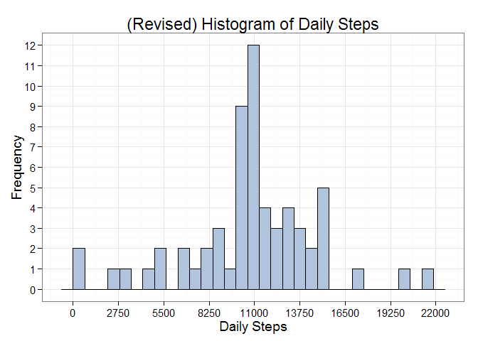

```r
print(
    ggplot(i) +
        geom_histogram(aes(x=steps),
                       col="black",
                       fill="lightsteelblue",
                       binwidth=diff(range(i$steps))/30) +
        scale_x_continuous(breaks=seq(0,22000,by=2750)) +
        scale_y_continuous(breaks=seq(0,12,by=1)) +
        theme_bw(base_size=14,base_family="sans") +
        labs(x="Daily Steps") +
        labs(y="Frequency") +
        labs(title="(Revised) Histogram of Daily Steps") +
        theme(plot.title = element_text(size = rel(1.25)))
)
```

Report mean and median of distribution inside of message.

```r
message(sprintf("For the \"revised\" distribution \"Daily Steps\"
    the mean is: %.0f, and the median is: %.0f", mean(i$steps), median(i$steps)))
```

```
## For the "revised" distribution "Daily Steps"
##     the mean is: 10766, and the median is: 10766
```

## Are there differences in activity patterns between weekdays and weekends?

Add a new ‘factor’ for ‘Weekday’ versus ‘Weekend’ whose underlying levels are lubridate values returned by ‘wday’ (1:7) where Sunday = 1 and Saturday = 7. Note: We don’t need to convert our ‘date’ factor to a POSIX compliant date since the lubridate ‘ymd’ function will do this in a construct like this: wday(ymd(date)). You can verify this with the construct: weekdays(ymd(date)).

```r
ddf <- ddf %>%
        mutate(day = factor(ifelse(wday(ymd(date)) %in% c(1,7),
               "Weekend", "Weekday")))
```

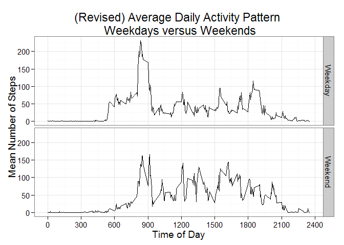

```r
j <- ddf %>%
        group_by(day, time = interval) %>%
            summarize(average = mean(steps, na.rm = TRUE)) %>%
                data.frame()
print(
    ggplot(data = j, aes(x = time, y = average)) +
        geom_line(color = "black", size = 0.5) +
        facet_grid(day ~ .) +
        labs(x = "Time of Day") +
        labs(y = "Mean Number of Steps") +
        labs(title = "(Revised) Average Daily Activity Pattern \n Weekdays versus Weekends") +
        theme(plot.title = element_text(hjust = 0.5)) +
        theme_bw(base_size=14,base_family="sans") +
        theme(plot.title = element_text(size = rel(1.25))) +
        scale_x_continuous(breaks=seq(0,2400,by=300))
)
```